# Phase Plane Analysis and Nonhomogeneous Systems

MATH 341 — Notes 11

University of Scranton

2026-10-04

# Goals

## What We Will Cover

1. **Table 4.1** and **Theorem 4.41** — eigenvalue classification and stability criterion $\text{tr}\,A<0$, $\det A>0$
2. **Theorem 4.40** — the trace–determinant plane; reading off the phase portrait type at a glance
3. **Drawing phase diagrams** — nullclines, direction fields, eigenvectors
4. **Applied examples** — crop–soil, glucose–insulin, circuits, chemical reactors
5. **Fundamental matrix** $\Phi(t)$ for homogeneous systems
6. **Variation of parameters** for nonhomogeneous systems $\mathbf{x}'=A\mathbf{x}+\mathbf{f}(t)$
7. **Undetermined coefficients** for nonhomogeneous systems

**Note**

**Sections 4.5 and 4.6** of (Logan 2015).

**Tip**

New vocabulary: trace–determinant plane, stability theorem, nullcline, fundamental matrix, variation of parameters (systems), undetermined coefficients (systems).

# Section 4.5

## Phase Plane Analysis

## Classification Summary (Table 4.1)

Eigenvalues of $A$ determine *everything* about the phase portrait of $\mathbf{x}' = A\mathbf{x}$:

| Eigenvalues | Portrait | Stability |
| --- | --- | --- |
| $\lambda_1,\lambda_2>0$, real, unequal | Unstable node | Unstable |
| $\lambda_1,\lambda_2<0$, real, unequal | Stable node | Asymp. stable |
| $\lambda_1<0<\lambda_2$ | Saddle | Unstable |
| $\lambda=\pm bi$ | Center | Stable |
| $\lambda=a\pm bi$, $a>0$ | Unstable spiral | Unstable |
| $\lambda=a\pm bi$, $a<0$ | Stable spiral | Asymp. stable |
| $\lambda_1=\lambda_2>0$ | Unstable node | Unstable |
| $\lambda_1=\lambda_2<0$ | Stable node | Asymp. stable |

**But we never need to compute eigenvalues to check stability:**

## Theorem 4.41 — The Stability Theorem

**Theorem 4.41**

The origin $(0,0)$ of $\mathbf{x}'=A\mathbf{x}$ is **asymptotically stable** if, and only if,
$$\text{tr}\,A < 0 \quad \text{and} \quad \det A > 0.$$

**Why this works:**

- $\det A > 0$: eigenvalues are either both-negative-real, or complex-conjugates (no zero eigenvalue, no opposite signs)
- $\text{tr}\,A = \lambda_1+\lambda_2 < 0$: real parts are negative

**Tip**

In applications: **compute $\text{tr}\,A$ and $\det A$ in terms of parameters**, then check their signs. This immediately settles stability without solving the characteristic equation.

## Theorem 4.40 — The Trace–Determinant Plane

The parabola $(\text{tr}\,A)^2 = 4\det A$ is the **discriminant boundary** separating real eigenvalues (below/on) from complex eigenvalues (above).

**Theorem 4.40**

Plot the point $(\text{tr}\,A,\, \det A)$. The region it falls in determines the portrait:

| Region | Portrait |
| --- | --- |
| $\det A < 0$ | **Saddle** |
| $\det A > 0$, $\text{tr}\,A = 0$ | **Center** |
| $\det A > 0$, $\text{tr}\,A > 0$, on/below parabola | **Unstable node** |
| $\det A > 0$, $\text{tr}\,A > 0$, above parabola | **Unstable spiral** |
| $\det A > 0$, $\text{tr}\,A < 0$, on/below parabola | **Stable node** |
| $\det A > 0$, $\text{tr}\,A < 0$, above parabola | **Stable spiral** |

## The Trace–Determinant Plane — Diagram

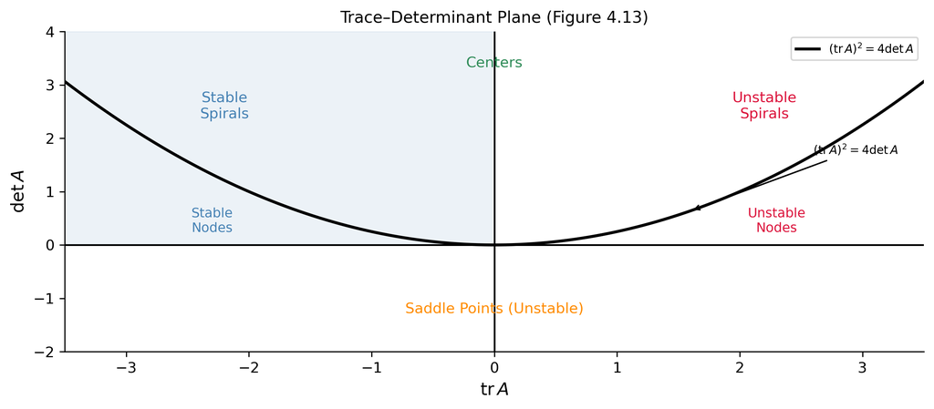

Figure 1

## Using the Trace–Determinant Plane

**Example.** Classify the origin for each system:

| System | $\text{tr}\,A$ | $\det A$ | Discriminant | Type |
| --- | --- | --- | --- | --- |
| $\begin{pmatrix}-2&-3\\3&-2\end{pmatrix}$ | $-4$ | $13$ | $16-52=-36<0$ | Stable spiral |
| $\begin{pmatrix}1&1\\4&1\end{pmatrix}$ | $2$ | $-3$ | — | Saddle |
| $\begin{pmatrix}-2&0\\0&-5\end{pmatrix}$ | $-7$ | $10$ | $49-40=9>0$ | Stable node |

**Tip**

**Workflow:** (1) Compute $\text{tr}\,A$ and $\det A$. (2) Check $\det A$: if $<0$, it’s a saddle. (3) If $\det A>0$, check $\text{tr}\,A$ for stability. (4) Compare $(\text{tr}\,A)^2$ to $4\det A$ for node vs. spiral.

## How to Draw a Phase Diagram

**(a) Real unequal eigenvalues:** Draw linear orbits along eigenvectors (arrows toward origin for $\lambda<0$, away for $\lambda>0$). Fill between with direction field. Add nullclines.

**(b) Purely imaginary eigenvalues ($\lambda=\pm bi$):** Orbits are closed ellipses. Compute one direction field vector to determine CW or CCW. Add nullclines.

**(c) Complex eigenvalues ($\lambda=a\pm bi$):** Orbits are spirals; sign of $a$ determines in vs. out. Compute one direction field vector for orientation.

**(d) $\det A = 0$:** Line of equilibria along $ax+by=0$. Orbits are parallel lines $y=mx+C$.

# Applied Examples

## Example 4.42 — Crop–Soil Model

Pesticide in crops ($x$) and soil ($y$):
$$x'=-\beta x+\alpha y, \quad y'=\beta x-(\alpha+\gamma)y, \quad \alpha,\beta,\gamma>0.$$

**Nullclines:** $x'=0$ on $y=(\beta/\alpha)x$; $\;y'=0$ on $y=\beta/(\alpha+\gamma)\,x$.

The $x$-nullcline has **greater slope** than the $y$-nullcline.

**Stability:** $\text{tr}\,A=-(\alpha+\beta+\gamma)<0$ and $\det A=\beta\gamma>0$.

$\implies$ **Asymptotically stable** by Theorem 4.41.

The pesticide eventually disappears from the system. $\square$

**Note**

We reached this conclusion **without solving the system** — just from $\text{tr}\,A$ and $\det A$. This is the power of the geometric approach.

## Example 4.42 — Phase Portrait

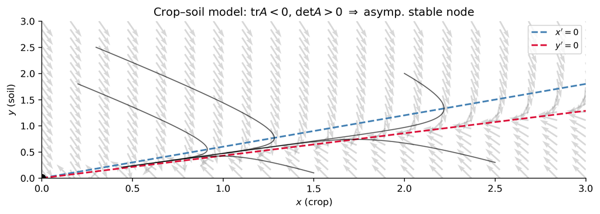

Figure 2

## Example 4.44 — Glucose–Insulin Dynamics

$$x'=-gx-ry,\quad y'=sx-dy, \quad A=\begin{pmatrix}-g&-r\\s&-d\end{pmatrix}, \quad g,r,s,d>0.$$

$\text{tr}\,A=-(g+d)<0$ and $\det A=gd+rs>0$ $\implies$ **always asymptotically stable**.

Eigenvalues: $\lambda=\tfrac{1}{2}\!\left(-(g+d)\pm\sqrt{(g-d)^2-4rs}\right)$.

| Condition | Eigenvalue type | Behavior |
| --- | --- | --- |
| $(g-d)^2>4rs$ | Real, negative | **Stable node** — monotone return |
| $(g-d)^2<4rs$ | Complex, $\text{Re}<0$ | **Stable spiral** — decaying oscillations (hypoglycemic overshoot) |

[figure not shown]

Figure 3

## Example 4.45 — Electrical Circuit

Two-loop circuit (capacitor $C$, resistor $R$, inductor $L$):

$$I_2'=\frac{1}{RC}(-I_2+I_3),\quad I_3'=-\frac{R}{L}I_2. \qquad
A=\begin{pmatrix}-\frac{1}{RC} & \frac{1}{RC}\\[4pt]-\frac{R}{L} & 0\end{pmatrix}.$$

$\text{tr}\,A=-1/(RC)<0$ and $\det A=1/(LC)>0$ $\implies$ always asymptotically stable.

$(\text{tr}\,A)^2-4\det A = \dfrac{1}{(RC)^2}-\dfrac{4}{LC}$:

| Condition | Type |
| --- | --- |
| $L/(R^2C)>4$ | **Node** (overdamped — no oscillations) |
| $L/(R^2C)<4$ | **Spiral** (underdamped — decaying oscillations) |

**Note**

The case $L/(R^2C)<4$ models a **resonant** RLC circuit — currents oscillate while decaying toward zero.

## Example 4.46 — Coupled Chemical Reactors

Two tanks, concentrations $C_1(t)$, $C_2(t)$ with $c_\text{in}=0$:

$$C_1'=-\frac{q_1}{V}C_1+\frac{q_2}{V}C_2, \qquad C_2'=\frac{q_1}{V}C_1-\frac{q_2+q}{V}C_2.$$

$$A=\begin{pmatrix}-q_1/V & q_2/V \\ q_1/V & -(q_2+q)/V\end{pmatrix}.$$

$\text{tr}\,A = -(q_1+q_2+q)/V < 0$ and $\det A = q_1 q/V^2 > 0$.

$\implies$ **Asymptotically stable.** Both concentrations $\to 0$ as $t\to\infty$. $\square$

# Section 4.6

## Nonhomogeneous Systems

## Setup

We now study the **nonhomogeneous** system

$$\mathbf{x}' = A\mathbf{x} + \mathbf{f}(t). \tag{4.43}$$

where $\mathbf{f}(t)=(f_1(t),f_2(t))^T$ is a prescribed forcing function.

**Structure of the general solution** (same as for scalar equations):

$$\mathbf{x}(t) = \underbrace{\mathbf{x}_h(t)}_{\text{homogeneous}} + \underbrace{\mathbf{x}_p(t)}_{\text{particular}}.$$

Two methods for finding $\mathbf{x}_p$:

1. **Variation of parameters** — works for any $\mathbf{f}(t)$
2. **Undetermined coefficients** — efficient when $\mathbf{f}(t)$ is a polynomial, exponential, sine/cosine, or their products

## The Fundamental Matrix

**Definition**

A **fundamental matrix** $\Phi(t)$ is a $2\times 2$ matrix whose **columns are two independent solutions** of the homogeneous system $\mathbf{x}'=A\mathbf{x}$:
$$\Phi(t)=\bigl(\mathbf{x}_1(t)\;\big|\;\mathbf{x}_2(t)\bigr).$$

**Key properties:**

- $\Phi'(t)=A\Phi(t)$ (satisfies the matrix ODE)
- General solution of homogeneous system: $\mathbf{x}_h(t)=\Phi(t)\mathbf{c}$ for arbitrary $\mathbf{c}=(c_1,c_2)^T$
- $\Phi(t)$ is invertible (columns are independent, so $\det\Phi\neq 0$)

## Variation of Parameters — Derivation

Assume a particular solution $\mathbf{x}(t)=\Phi(t)\mathbf{c}(t)$ (vary the constants).

**Differentiate:**
$$\mathbf{x}'(t)=\Phi(t)\mathbf{c}'(t)+\Phi'(t)\mathbf{c}(t)=\Phi(t)\mathbf{c}'(t)+A\Phi(t)\mathbf{c}(t).$$

**Set equal to** $A\mathbf{x}+\mathbf{f}(t)$:
$$\Phi(t)\mathbf{c}'(t)=\mathbf{f}(t)\implies \mathbf{c}'(t)=\Phi(t)^{-1}\mathbf{f}(t).$$

**$\Phi(t)^{-1}$ Is Time-Varying**

$\Phi(t)^{-1}$ is **not** a constant matrix — it is the matrix inverse evaluated at each $t$ separately, using the time-varying entries of $\Phi(t)$. For a $2\times 2$ fundamental matrix this means applying the inverse formula
$$\Phi(t)^{-1} = \frac{1}{\det\Phi(t)}\begin{pmatrix}d(t)&-b(t)\\-c(t)&a(t)\end{pmatrix}$$
at every $t$, where $\det\Phi(t)$ is the Wronskian $W(t)$. This is **distinct** from the constant-matrix inverse $A^{-1}$ from Section 4.2.

**Integrate:**

**Variation of Parameters Formula (4.45)**

$$\mathbf{x}(t)=\underbrace{\Phi(t)\mathbf{k}}_{\text{general homogeneous}}+\underbrace{\Phi(t)\int_0^t\Phi(s)^{-1}\mathbf{f}(s)\,ds}_{\text{particular solution}}.$$

## Example 4.47 — Variation of Parameters

$$\mathbf{x}'=\begin{pmatrix}4&3\\-1&0\end{pmatrix}\mathbf{x}+\begin{pmatrix}0\\t\end{pmatrix}.$$

**Eigenpairs:** $\lambda_1=1$, $\mathbf{v}_1=(1,-1)^T$; $\;\lambda_2=3$, $\mathbf{v}_2=(-3,1)^T$.

$$\Phi(t)=\begin{pmatrix}e^t&-3e^{3t}\\-e^t&e^{3t}\end{pmatrix},\qquad
\Phi^{-1}(t)=-\frac{1}{2}\begin{pmatrix}e^{-t}&3e^{-t}\\e^{-3t}&e^{-3t}\end{pmatrix}.$$

**Note**

$\Phi^{-1}(t)$ is computed by applying the $2\times 2$ inverse formula to $\Phi(t)$ at each $t$: $\det\Phi(t) = e^t\cdot e^{3t} - (-3e^{3t})(-e^t) = e^{4t}-3e^{4t} = -2e^{4t}$, so $\Phi^{-1}(t) = \tfrac{1}{-2e^{4t}}\bigl[\begin{smallmatrix}e^{3t}&3e^{3t}\\e^t&e^t\end{smallmatrix}\bigr]$, which simplifies to the expression above.

After evaluating the integrals by parts, formula (4.45) gives:

$$\mathbf{x}(t)=\begin{pmatrix}k_1e^t-3k_2e^{3t}\\-k_1e^t+k_2e^{3t}\end{pmatrix}
+\begin{pmatrix}t+\tfrac{4}{3}\\[4pt]-\tfrac{4}{3}t-\tfrac{13}{9}\end{pmatrix}.\;\square$$

**Tip**

The particular solution has the same polynomial degree as $\mathbf{f}(t)$ — a degree-1 forcing gives a degree-1 particular solution.

## Undetermined Coefficients for Systems

**Strategy**

Guess $\mathbf{x}_p$ to match the form of $\mathbf{f}(t)$. If a term appears in **one** component of $\mathbf{f}$, it must appear in **all** components of the guess.

| $\mathbf{f}(t)$ contains | Guess for $\mathbf{x}_p$ |
| --- | --- |
| Polynomial degree $n$ | $\mathbf{x}_p=\mathbf{a}_n t^n+\cdots+\mathbf{a}_0$ |
| $e^{\mu t}$ ($\mu\neq$ eigenvalue) | $\mathbf{x}_p=\mathbf{a}e^{\mu t}$ |
| $\cos\omega t$ or $\sin\omega t$ | $\mathbf{x}_p=\mathbf{a}\cos\omega t+\mathbf{b}\sin\omega t$ |

Rules are **identical** to the scalar case from Chapter 2.

## Example 4.49 — Undetermined Coefficients

Revisit Example 4.47. $\mathbf{f}(t)=(0,t)^T$ is linear, so guess

$$\mathbf{x}_p=\begin{pmatrix}at+b\\ct+d\end{pmatrix}.$$

Substitute $\mathbf{x}_p'=A\mathbf{x}_p+\mathbf{f}$:
$$\begin{pmatrix}a\\c\end{pmatrix}=\begin{pmatrix}4&3\\-1&0\end{pmatrix}\begin{pmatrix}at+b\\ct+d\end{pmatrix}+\begin{pmatrix}0\\t\end{pmatrix}.$$

Comparing coefficients of $t$ and constants:

$$a=1,\quad b=-c=\frac{4}{3},\quad d=-\frac{13}{9}.$$

$$\mathbf{x}_p=\begin{pmatrix}t+\tfrac{4}{3}\\[4pt]-\tfrac{4}{3}t-\tfrac{13}{9}\end{pmatrix}.\;\square$$

Agrees exactly with the variation of parameters result — **much less work!**

## Example 4.48 — Guessing for Higher-Degree Forcing

If the forcing is $\mathbf{f}(t)=\begin{pmatrix}1\\t^2+2\end{pmatrix}$, the highest degree is 2, so we guess

$$\mathbf{x}_p(t)=\begin{pmatrix}a_1t^2+b_1t+c_1\\a_2t^2+b_2t+c_2\end{pmatrix}.$$

Both components are degree 2, regardless of which component of $\mathbf{f}$ has which degree. Substituting and comparing coefficients determines the six unknowns $a_1,b_1,c_1,a_2,b_2,c_2$. $\square$

**Tip**

When $\mathbf{f}(t)$ is complicated or involves resonance (forcing frequency = eigenvalue), **variation of parameters** is always available as a fallback. For simple $\mathbf{f}$, undetermined coefficients is faster.

# Summary

## Key Takeaways

- The **trace–determinant plane** (Figure 4.13, Theorem 4.40) gives a complete map: locate $(\text{tr}\,A,\,\det A)$ to read off the portrait type without computing eigenvalues. The parabola $(\text{tr}\,A)^2 = 4\det A$ separates nodes from spirals.
- **Theorem 4.41**: the origin is asymptotically stable $\iff$ $\text{tr}\,A<0$ **and** $\det A>0$. In applied problems this reduces stability analysis to checking two simple inequalities.
- **Nullclines** ($x'=0$ and $y'=0$) are powerful tools for sketching phase portraits. On the $x$-nullcline the vector field is vertical; on the $y$-nullcline it is horizontal. Together with one computed direction-field vector per region, the qualitative behavior is completely determined.
- For the **nonhomogeneous system** $\mathbf{x}'=A\mathbf{x}+\mathbf{f}(t)$: the fundamental matrix $\Phi(t)$ (columns = independent homogeneous solutions) is the key object. The **variation of parameters formula** (4.45) always works; **undetermined coefficients** is faster when $\mathbf{f}$ is a polynomial, exponential, or sinusoid.
- In all applied models (crop–soil, glucose–insulin, circuits, reactors): **stability follows immediately from $\text{tr}\,A$ and $\det A$**, without ever solving the characteristic equation. The geometric approach is often all that is needed.

**Tip**

**Looking Ahead:** These techniques extend to **nonlinear systems** in Chapter 5. Near an equilibrium $\mathbf{x}^*$ the linearization (Jacobian) governs local behavior — the same trace–determinant classification applies to the Jacobian.

**Note**

**Next:** Nonlinear Systems and Linearization — Logan §5.1–5.2.

## References

Logan, J David. 2015. *A First Course in Differential Equations, Third Edition*.